# El dominio de ‘La Roja’ en la Eurocopa 2024: Del campo a los gráficos

Ricard Castillo Moustakim, Elena Fernández Caro, Carlos Jiménez Ortega, Daniel Prados Serrano, Lourdes María Vargas Gamez, Mateo Vega Pueyo

07/06/2026

# Introducción

Actualmente, la extracción de datos en el fútbol genera miles de registros por encuentro. Desde coordenadas espaciales hasta trayectorias de pases o métricas de rendimiento físico, información que suele acabar almacenada en un dataset de gran tamaño cuya interpretación requiere herramientas adecuadas de análisis y visualización. El problema ya no radica en la recolección, sino en la interpretación. Tener una tabla cruda cargada en nuestro entorno de R sirve de poco si no logramos extraer conclusiones tácticas claras.

En esta vignette planteamos la visualización como solución a este dilema. Para procesar y comunicar la información, recurrimos a `.ggplot2`, estructurando los gráficos mediante su sistema de capas clásico para graficar variables con una mayor calidad visual de cara al análisis posterior. Sin embargo, dada la naturaleza dinámica del juego, las representaciones estáticas a veces resultan insuficientes. Para solventarlo, integramos `gganimate`, lo que nos permite renderizar animaciones y evaluar la progresión temporal de los eventos sobre el campo.

Para ir más allá, queremos que todo el trabajo siga un hilo común: ¿Qué factores relacionados con el rendimiento colectivo pueden explicar el éxito de la Selección Española en la Eurocopa 2024?. Nos adentraremos de lleno en los paquetes mencionados a la vez que analizamos las claves del éxito de la roja en su paso por la competición de máximo nivel europeo en cuanto a selecciones.

# 1. Los Cimientos Visuales: Fundamentos de `ggplot2`

Para entender el funcionamiento de las visualizaciones que generaremos más adelante, partimos del paquete `ggplot2`. Esta librería no opera como un conjunto de funciones independientes que devuelven gráficos. Por el contrario, se apoya en la conocida como *Grammar of Graphics* de Leland Wilkinson, estructurando cada representación mediante componentes superpuestos en capas.

Veamos a continuación los parámetros básicos.

## 1.1 Inicialización y estructura de datos: `data` y `ggplot()`

La ejecución arranca siempre con la llamada a `ggplot()`. Su argumento principal es `data`, donde pasamos el dataset estructurado, habitualmente un `data.frame` o un *tibble*.

Si probamos a ejecutar un chunk que contenga únicamente `ggplot(data = pases)`, lo único que R genera es un panel gris vacío al no haber añadido las variables ni el tipo de gráfico que deseamos pintar.

## 1.2 Mapeo de variables: La función `aes()`

Para conectar los datos con una representación visual tenemos que asignar las variables a cada eje. Esto lo hacemos asignando los parámetros correspondientes dentro de la función `aes()`. Aquí es donde establecemos la estructura concreta:

- **`x` e `y`**: Definen los ejes, vinculando las columnas de nuestro dataset a una posición bidimensional.
- **`col` (o `color`)**: Al pasarle una variable categórica, como el nombre del equipo, `ggplot2` agrupa directamente según esta variable. Asigna automáticamente una paleta de colores a los distintos niveles de la variable y construye la leyenda.

Hay que tener en cuenta que dentro de `aes()` exclusivamente mapeamos variables. En caso de por ejemplo querer asignar un único color a toda la muestra, tendríamos que declarar el argumento fuera de esta función.

## 1.3 Adición de capas (`+`) y anotaciones (`labs`)

Una vez definidos los datos y el mapeo, empezamos a añadir elementos a la gráfica utilizando el operador `+`. La primera capa suele corresponder a la geometría, denotada por la familia de funciones `geom_`. Esta orden materializa los datos en una forma física concreta, como pueden ser puntos, líneas o polígonos.

Cualquier salida gráfica para realizar un análisis necesita contexto. Mediante `labs()` introducimos los textos descriptivos para mantener el rigor académico del documento, especificando el `title`, el `subtitle` y rotulando los ejes `x` e `y` junto a sus unidades de medida o rangos.

## 1.4 Generación del primer gráfico exploratorio

Aplicando estos conceptos, veamos un primer ejemplo para nuestros datos. Graficamos la distancia del pase frente a su ángulo de ejecución, asignando un color distinto a cada selección nacional para observar la distribución espacial inicial y detectar posibles patrones.

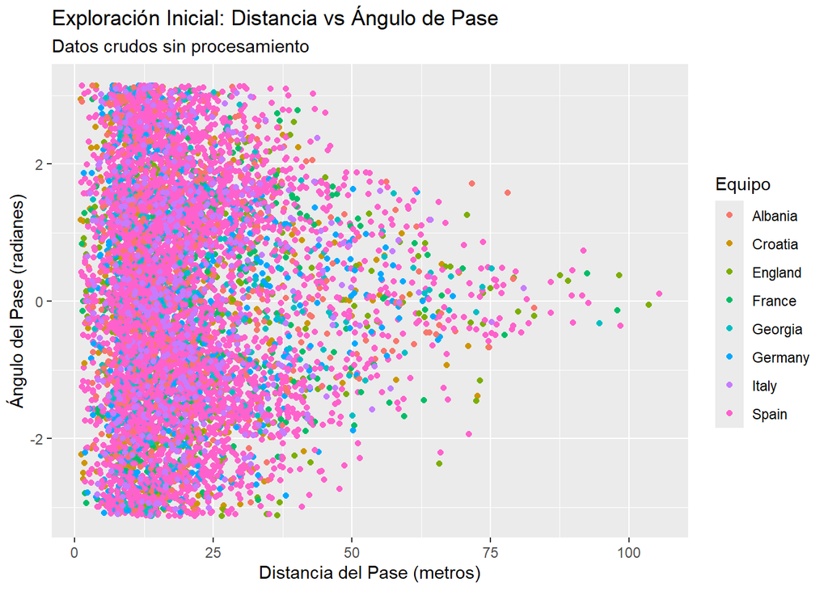

```r
pases <- read_csv("pases_espana.csv")
# Ensamblaje paso a paso usando la Gramática de los Gráficos
ggplot(data = pases, aes(x = pass.length, y = pass.angle, col = team.name)) +

  # CAPA FÍSICA: Representamos cada fila de datos como un punto
  geom_point() +

  # CAPA DE CONTEXTO: Nombramos todos los elementos de forma clara
  labs(
    title = "Exploración Inicial: Distancia vs Ángulo de Pase",
    subtitle = "Datos crudos sin procesamiento",
    x = "Distancia del Pase (metros)",
    y = "Ángulo del Pase (radianes)",
    col = "Equipo"
  )
```

En esta gráfica podemos ver la correcta proyección de los datos, R los procesa y genera la leyenda por equipos de forma automática. Sin embargo, al proyectar tantos datos, nos encontramos con un problema bastante común en estadística computacional: el *overplotting*. Básicamente, la acumulación de tanta información en un gráfico genera ruido visual que acaba imposibilita cualquier análisis.

Nuestra idea mediante esta observación era relacionar la distancia de los pases y el ángulo con el que se realizaban. Concretamente, un ángulo de 0 radianes representa un pase hacia alante, uno de $-\pi$ o $\pi$ representa un pase hacia atrás y un ángulo de $-\pi/2$ o $\pi/2$ representa uno lateral. En este caso, como ya hemos comentado, debido a la gran cantidad de datos, no somos capaces de observarlos de forma correcta, siendo imposible incluso distinguir según la selección.

# 2. Profundizando en la Estructura Visual

Los gráficos iniciales nos dan una idea de los datos pero presentan un problema que puede ser resuelto usando el paquete ggplot2: el solapamiento visual. En nuestro caso particular el tener registradas estadísticas de tal número de jugadores hace imposible sacar conclusiones claras si nos quedásemos ahí.

Durante todo el punto 2 usaremos también las funciones theme_(), con esto refinamos nuestras gráficas, eliminando los fondos grises o cuadrículas densas. Principalmente usaremos la función theme_minimal() que limpia el lienzo. Además, también haremos uso de scale(), el cual comentaremos más adelante.

## 2.1 El control de las formas: La familia `geom_`

Ante la imposibilidad de dibujar de forma precisa nuestros datos aparece geom_ que le dice a R cómo dibujar los datos. Dentro de cualquier geom_() podemos meter diferentes argumentos, como por ejemplo: color (color de la línea o borde), fill (relleno), alpha (transparencia), size (tamaño), etc.

### geom_point() y geom_text()

Veamos el uso de geom_point() y geom_text(), cuyos usos nos permiten hacer un mapa de dispersión y ponerles nombre, respectivamente.

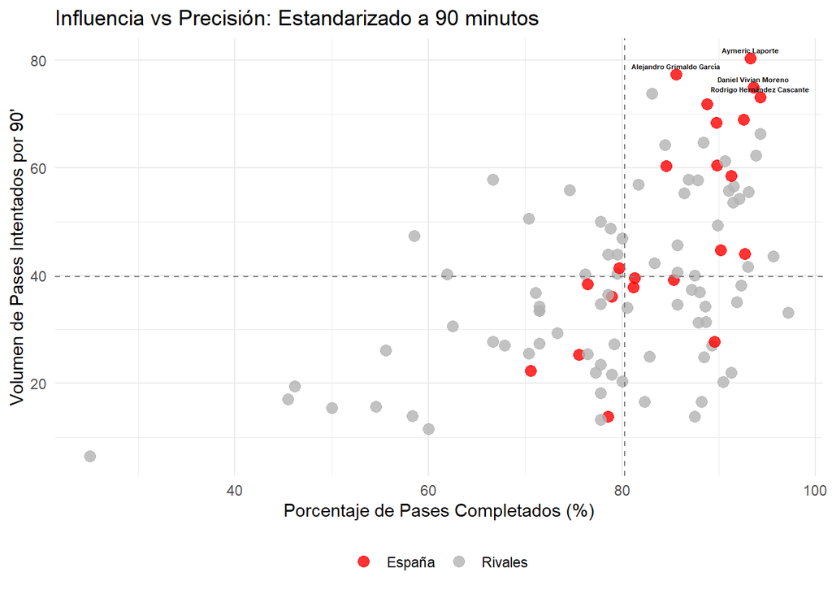

```r
# Cargamos ambos conjuntos de datos
pases <- read_csv("pases_espana.csv")
minutos <- read_csv("minutos_jugadores_espana.csv")

# Resumen de pases y cálculo del porcentaje de acierto
pases_resumen <- pases %>%
  mutate(pase_completado = is.na(pass.outcome.name)) %>%
  group_by(player.name, team.name) %>%
  summarise(
    total_pases = n(),
    pases_buenos = sum(pase_completado),
    porcentaje_acierto = (pases_buenos / total_pases) * 100,
    .groups = "drop"
  )

# Cruzamos los datos y estandarizamos a 90 minutos
datos_estandarizados <- pases_resumen %>%
  # Juntamos los pases con los minutos usando el nombre del jugador
  inner_join(minutos, by = c("player.name", "team.name")) %>%
  # Filtramos a los que han jugado al menos 45 minutos (medio partido) para evitar anomalías
  filter(minutos_totales > 45) %>%
  # Aplicamos una normalización para que los pases sean por 90 minutos
  mutate(
    pases_por_90 = (total_pases / minutos_totales) * 90,
    Es_Espana = ifelse(team.name == "Spain", "España", "Rivales")
  )

# Creamos el gráfico
ggplot(datos_estandarizados, aes(x = porcentaje_acierto, y = pases_por_90, color = Es_Espana)) +

  # GEOM: Puntos y Textos
  geom_point(alpha = 0.8, size = 3) +

  geom_text(data = subset(datos_estandarizados, team.name == "Spain" & (pases_por_90 > 75 | porcentaje_acierto > 93)),
            aes(label = player.name),
            vjust = -1, size = 1.5, color = "black", fontface = "bold") +

  # GEOM: Líneas de referencia con la media
  geom_vline(xintercept = mean(datos_estandarizados$porcentaje_acierto), linetype = "dashed", color = "gray50") +
  geom_hline(yintercept = mean(datos_estandarizados$pases_por_90), linetype = "dashed", color = "gray50") +

  # SCALE y THEME:
  scale_color_manual(values = c("España" = "red", "Rivales" = "gray70")) +
  theme_minimal(base_family = "sans") +
  theme(legend.position = "bottom",
        legend.title = element_blank()) +

  # LABS: Títulos reflejando la métrica
  labs(title = "Influencia vs Precisión: Estandarizado a 90 minutos",
       x = "Porcentaje de Pases Completados (%)",
       y = "Volumen de Pases Intentados por 90'")
```

Podemos apreciar que prácticamente la mitad de la plantilla de la selección española se encuentra en el cuadrante superior derecho. Esto muestra la clara dominancia de la roja frente al resto de selecciones, destacando una defensa sólida con el balón en los pies y al cerebro del equipo: Rodri.

### geom_col()

Para poder mostrar cantidades comparando categorías podemos usar: geom_col().

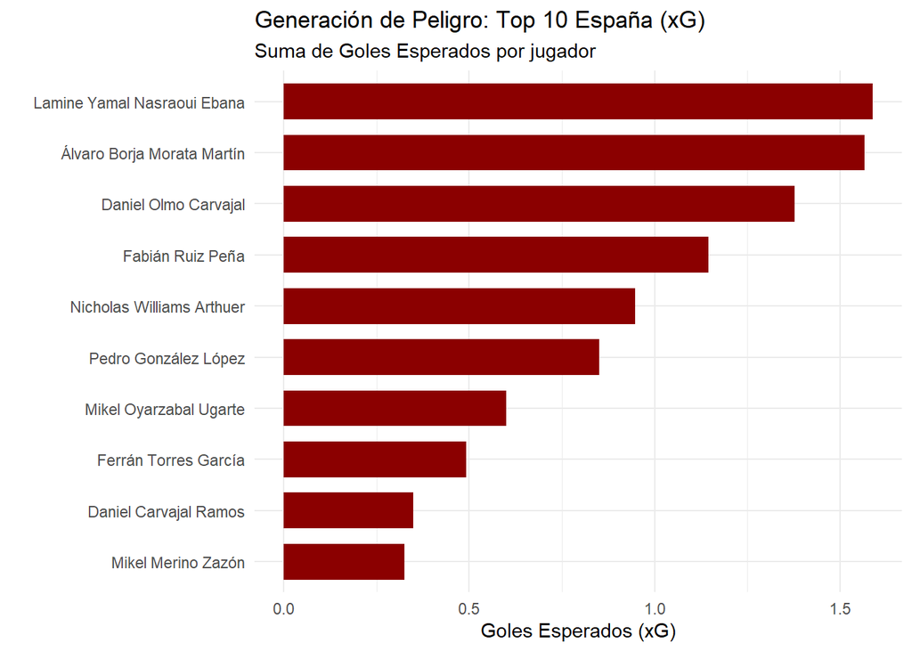

```r
tiros<-read.csv("tiros_espana.csv")
# Sumamos el xG por jugador solo para España
xg_espana <- tiros %>%
  filter(team.name == "Spain") %>%
  group_by(player.name) %>%
  summarise(xG_total = sum(shot.statsbomb_xg, na.rm = TRUE)) %>%
  arrange(desc(xG_total)) %>%
  head(10) # Cogemos el Top 10

# El Gráfico
# reorder() ordena las barras de mayor a menor
ggplot(xg_espana, aes(x = reorder(player.name, xG_total), y = xG_total)) +

  # GEOM: Usamos fill para rellenar la barra de rojo oscuro
  geom_col(fill = "darkred", width = 0.7) +

  coord_flip() + #Giramos el gráfico para que los nombres se lean bien
  theme_minimal() +
  labs(title = "Generación de Peligro: Top 10 España (xG)",
       subtitle = "Suma de Goles Esperados por jugador",
       x = "",
       y = "Goles Esperados (xG)")
```

Esto nos revela de forma clara lo que ya intuíamos viendo a nuestro equipo por la televisión: quiénes son los jugadores con mayor influencia en la generación de ocasiones del equipo. Dejando a Lamine Yamal, Morata y Dani Olmo como los mayores exponentes de la selección (nada nuevo).

### geom_boxplot()

Si queremos mostrar la distribución de los datos para poder encontrar posibles outliers geom_boxplot() nos permite crear diagramas de cajas, resolviéndonos el problema.

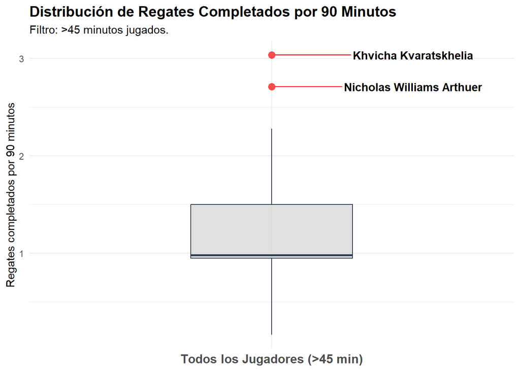

```r
# Leemos los dos archivos CSV
df_regates <- read.csv("regates_espana.csv", stringsAsFactors = FALSE)
df_minutos <- read.csv("minutos_jugadores_espana.csv", stringsAsFactors = FALSE)

# Filtramos por regates COMPLETADOS y contar por jugador
regates_completos_df <- df_regates %>%
  filter(dribble.outcome.name == "Complete") %>%
  group_by(player.name) %>%
  summarise(regates_completos_totales = n(), .groups = "drop")

# Unimos con minutos, filtrar por >45 min y calcular la métrica por 90 minutos
datos_boxplot <- regates_completos_df %>%
  inner_join(df_minutos, by = "player.name") %>%
  filter(minutos_totales > 45) %>%
  mutate(regates_comp_por_90 = (regates_completos_totales / minutos_totales) * 90)

# Creamos el Boxplot identificando matemáticamente a los outliers para sus nombres
ggplot(datos_boxplot, aes(x = "Todos los Jugadores (>45 min)", y = regates_comp_por_90)) +
  # Boxplot estándar: dibuja la caja y sus outliers en rojo
  geom_boxplot(
    fill = "lightgray",
    color = "#2c3e50",
    alpha = 0.7,
    width = 0.4,
    outlier.colour = "red",
    outlier.shape = 16,
    outlier.size = 3
  ) +
  # Colocamos el nombre del jugador SOLO si es un outlier
  geom_text_repel(
    aes(label = ifelse(
      regates_comp_por_90 > quantile(regates_comp_por_90, 0.75) + 1.5 * IQR(regates_comp_por_90) |
      regates_comp_por_90 < quantile(regates_comp_por_90, 0.25) - 1.5 * IQR(regates_comp_por_90),
      player.name, ""
    )),
    color = "black",
    fontface = "bold",
    size = 3.8,
    box.padding = 0.5,
    point.padding = 0.3,
    segment.color = "red",
    nudge_x = 0.35,
    direction = "y"
  ) +
  labs(
    title = "Distribución de Regates Completados por 90 Minutos",
    subtitle = "Filtro: >45 minutos jugados.",
    x = NULL,
    y = "Regates completados por 90 minutos"
  ) +
  theme_minimal() +
  theme(
    axis.text.x = element_text(size = 12, face = "bold"),
    plot.title = element_text(face = "bold", size = 14)
  )
```

Este gráfico muestra una de las claves de nuestro juego y, sobre todo, del espectáculo visual que resultaba ver cada partido: la magia de Nico Williams. El hecho de que Nico sobresalga en esta gráfica de regates es muestra del descaro ofensivo en su juego y una de las razones por las que atormentaba a los defensas rivales. Además, observamos la presencia de otro outlier, Kvaratskhelia. Esto no hace más que demostrar el innegable talento del georgiano que, con su desborde, logró completar 3 de 4 regates en los primeros 30 minutos, ayudando a su selección a mantenerse por delante en el marcador. Sin embargo, esto enaltece aún más el nivel defensivo del conjunto español, que, después de unos primeros minutos algo perdido dentro del campo, logró rehacerse para neutralizar por completo a la estrella rival.

### geom_segment()

Aunque a nivel abstracto dibujar una línea entre dos puntos puede ser algo no muy útil, en el contexto de deportes u otras representaciones espaciales sí puede serlo, geom_segment() es precisamente lo que nos lo permite.

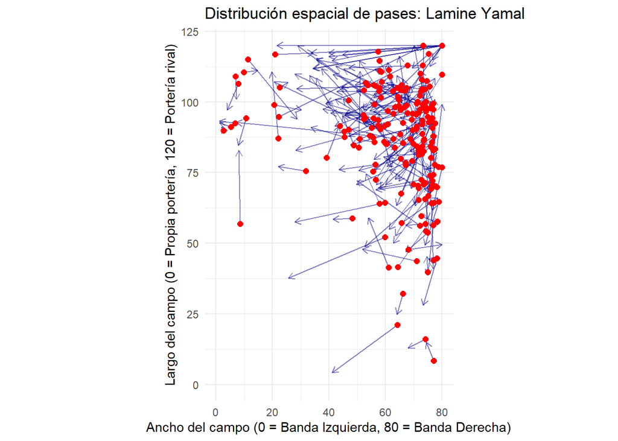

```r
pases_yamal <- pases %>%
  filter(player.name == "Lamine Yamal Nasraoui Ebana")

# El Gráfico Espacial
ggplot(pases_yamal) +

  # GEOM 1: Trayectorias. Mapeamos location_y al eje X, y location_x al eje Y.
  geom_segment(aes(x = location_y, y = location_x,
                   xend = pass_end_y, yend = pass_end_x),
               color = "darkblue", alpha = 0.5, arrow = arrow(length = unit(0.2, "cm"))) +

  # GEOM 2: Puntos de inicio. Mapeo idéntico.
  geom_point(aes(x = location_y, y = location_x), color = "red", size = 2) +

  # ESCALAS Y COORDENADAS:
  # coord_fixed() es vital. Fuerza a que 1 unidad en el eje X mida exactamente
  # lo mismo en la pantalla que 1 unidad en el eje Y. Sin esto, R deforma el gráfico.
  coord_fixed(xlim = c(0, 80), ylim = c(0, 120)) +

  # TEMA: Limpio y académico
  theme_minimal() +

  # ETIQUETAS
  labs(title = "Distribución espacial de pases: Lamine Yamal",
       x = "Ancho del campo (0 = Banda Izquierda, 80 = Banda Derecha)",
       y = "Largo del campo (0 = Propia portería, 120 = Portería rival)")
```

Este gráfico permite visualizar la distribución espacial de los pases de la joven estrella, Lamine Yamal y observar las zonas del campo en las que interviene con mayor frecuencia. Vemos como gracias a poder unir dos puntos y a la riqueza de nuestra base de datos, podemos generar un mapa que represente el campo donde podamos representar los pases del jugador español. Poniendo así en evidencia la importancia del jugador en la creación de juego y sus tan reconocidos pases peligrosos al área.

## 2.2 Desglose analítico: La familia facet_

Para poder transformar un gráfico incomprensible en un, digamos, panel de control, usaremos Las Facetas: facet_(). En la representación visual de las estadísticas cuando tenemos muchas categorías a veces pintar todo a la vez es un caos. Las funciones facet_() resuelven esto creando múltiplos en un mismo gráfico. Veamos las dos funciones principales:

Para evaluar alguna característica de nuestros datos sin tener que filtrar el dataset en n tablas facet_wrap() divide el propio lienzo como deseemos. Variando ncol/nrow y scales modificaremos el número de columnas/ filas y los ejes, respectivamente, adaptando el gráfico de la forma que más nos convenga.

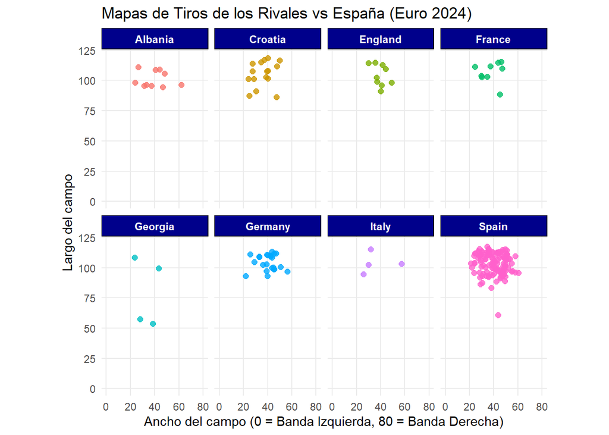

```r
# El Gráfico Facetado en vertical
# Intercambiamos los ejes: X = ancho (location_y), Y = largo (location_x)
ggplot(tiros, aes(x = location_y, y = location_x, color = team.name)) +

  # Añadimos los puntos de los tiros
  geom_point(alpha = 0.8, size = 2) +

  # FACET: Dividimos en paneles según el nombre del equipo
  facet_wrap(~ team.name, ncol = 4) +

  # PROPORCIÓN MATEMÁTICA: Mantenemos el rigor académico con 1:1
  # Ahora X va hasta 80 y Y va hasta 120
  coord_fixed(xlim = c(0, 80), ylim = c(0, 120)) +

  # TEMA: Limpio
  theme_minimal() +

  # Limpieza de la interfaz
  theme(legend.position = "none",
        strip.background = element_rect(fill = "darkblue"),
        strip.text = element_text(color = "white", face = "bold"),
        panel.grid.minor = element_blank()) + # Quitamos algunas líneas para limpiar más

  labs(title = "Mapas de Tiros de los Rivales vs España (Euro 2024)",
       x = "Ancho del campo (0 = Banda Izquierda, 80 = Banda Derecha)",
       y = "Largo del campo")
```

Como se puede apreciar fácilmente, si juntásemos todos los gráficos en uno sería un absoluto caos, no nos permitiría sacar conclusiones claras. Sin embargo, de esta manera, se puede apreciar la diferencia ofensiva entre unos equipos y otros de forma legible. En el caso de nuestra selección, observamos un volumen claramente superior a las demás. Sin embargo, esto se debe a que los datos utilizados solo recogen un partido del resto de conjuntos mientras que “La Roja” jugó en todos ellos. Es por esto que posteriormente pasaremos a realizar un análisis partido a partido para así poder llegar a conclusiones más claras.

Una alternativa para hacerlo más estricto es facet_grid(), que genera una matriz 2D con solo dos variables.

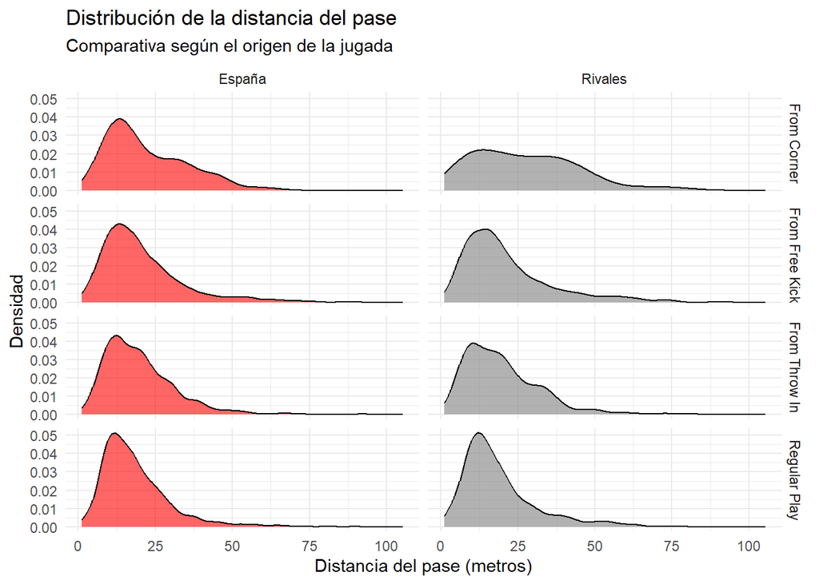

```r
# Simplificamos: Creamos columna para separar a España de sus rivales
pases <- pases %>%
  mutate(Es_Espana = ifelse(team.name == "Spain", "España", "Rivales"))

# Filtramos los inicios de jugada más comunes para que el gráfico no sea gigante
pases_filtrados <- pases %>%
  filter(play_pattern.name %in% c("Regular Play", "From Throw In", "From Free Kick", "From Corner"))

# El Gráfico con Facet Grid
ggplot(pases_filtrados, aes(x = pass.length, fill = Es_Espana)) +

  # Usamos un gráfico de densidad
  geom_density(alpha = 0.6) +

  # FACET GRID: Filas = Patrón de juego, Columnas = España vs Rivales
  facet_grid(play_pattern.name ~ Es_Espana) +

  scale_fill_manual(values = c("España" = "red", "Rivales" = "gray50")) +
  theme_minimal() +
  theme(legend.position = "none") + # Ocultamos la leyenda
  labs(title = "Distribución de la distancia del pase",
       subtitle = "Comparativa según el origen de la jugada",
       x = "Distancia del pase (metros)",
       y = "Densidad")
```

Este tipo de gráficos es mucho más selectivo, más estricto, permitiéndonos cruzar dos variables solas. Esto a veces nos revela información que no veríamos de otra manera, en nuestro caso podemos cruzar “Quién da el pase” con “De dónde viene la jugada”, mostrando un patrones tácticos muy interesantes: España no regala los corners, jugamos en corto para continuar la jugada, seguir dominando y manteniendo el balón. Además, observamos un escalón en la gráfica de la densidad de pases al sacar de banda de los rivales, lo que muestra que los obligamos a los a sacar de banda en largo debido a la asfixia constante de nuestros jugadores. Resultados sorprendente que de otra manera no veríamos.

## 2.3 Consistencia y personalización visual: scale_.

A veces los gráficos no son todo lo consistentes que deberían ser a nivel visual, una manera de solucionar esto es usar scale_(), permitiéndonos llevar la personalización a otro nivel. Por ejemplo: scale_color_manual() puede ayudarnos a añadir color a variables y hacer que se diferencien fácilmente o scale_x_continuous() y scale_y_continuous() para fijar límites y sobrescribir marcas numéricas con etiquetas de texto. Esto hace que estéticamente nuestras gráficas mejoren considerablemente, además de darnos niveles extra de información. Veámoslo:

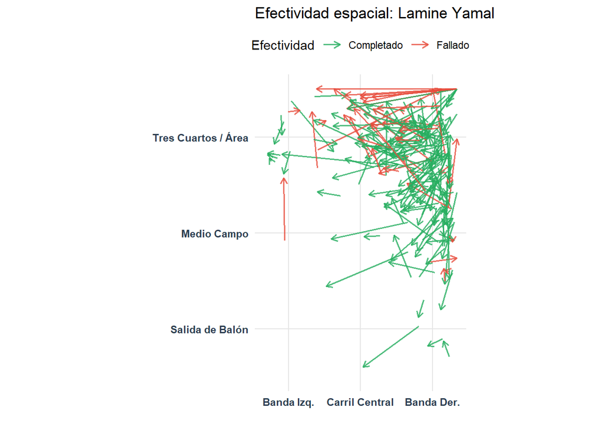

```r
# Cargamos y preparamos el dato de Lamine
pases <- read_csv("pases_espana.csv")

pases_yamal <- pases %>%
  filter(player.name == "Lamine Yamal Nasraoui Ebana") %>%
  # Creamos la variable de acierto: Si está vacío (NA), es que el pase llegó bien
  mutate(pase_completado = ifelse(is.na(pass.outcome.name), "Completado", "Fallado"))

# GRÁFICO MEJORADO CON ESCALAS
ggplot(pases_yamal) +

  # GEOM: Ahora mapeamos el COLOR al acierto del pase
  geom_segment(aes(x = location_y, y = location_x,
                   xend = pass_end_y, yend = pass_end_x,
                   color = pase_completado),
               alpha = 0.8, arrow = arrow(length = unit(0.2, "cm")), linewidth = 0.7) +

  coord_fixed(xlim = c(0, 80), ylim = c(0, 120)) +

  # Escala de Color:
  scale_color_manual(
    name = "Efectividad",
    values = c("Completado" = "#27ae60", "Fallado" = "#e74c3c") # Verde y Rojo exactos
  ) +

  # Escala X: Cambiamos el ancho (0 a 80) por Zonas Tácticas
  scale_x_continuous(
    breaks = c(10, 40, 70),
    labels = c("Banda Izq.", "Carril Central", "Banda Der.")
  ) +

  # Escala Y: Cambiamos el largo (0 a 120) por Zonas de Avance
  scale_y_continuous(
    breaks = c(20, 60, 100),
    labels = c("Salida de Balón", "Medio Campo", "Tres Cuartos / Área")
  ) +

  # TEMA: Limpieza final
  theme_minimal(base_family = "sans") +
  theme(
    legend.position = "top",
    panel.grid.minor = element_blank(), # Quitamos rayas innecesarias
    panel.grid.major = element_line(color = "gray90"),
    axis.text = element_text(face = "bold", color = "#2c3e50") # Ejes en negrita para que destaquen
  ) +

  labs(title = "Efectividad espacial: Lamine Yamal", x = "", y = "")
```

```r
  # Dejamos los títulos de ejes vacíos porque las etiquetas ya lo explican
```

Editando el gráfico anterior, podemos encontrar nueva información añadiendo color a las líneas: verde en los pases realizados con éxito y rojo los fallidos. Además de la posición específica del campo con etiquetas desde donde se realizó el pase. Esto completa el gráfico y nos muestra además la efectividad de nuestro jugador estrella.

Podemos añadir un argumento de ggplot y el paquete ggsoccer para mejorar esta gráfica y que quede lo más realista posible:

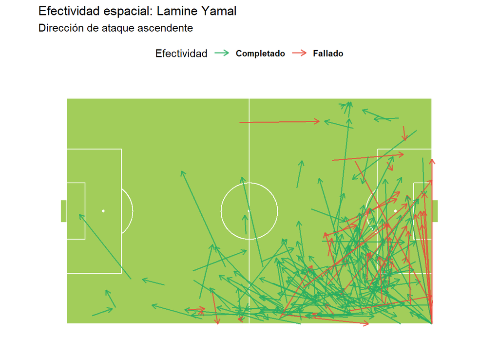

```r
# Preparamos los datos
pases <- read_csv("pases_espana.csv")

pases_yamal <- pases %>%
  filter(player.name == "Lamine Yamal Nasraoui Ebana") %>%
  mutate(pase_completado = ifelse(is.na(pass.outcome.name), "Completado", "Fallado"))

# GRÁFICO FINAL
ggplot(pases_yamal) +

  # Añadimos el campo de fondo
  annotate_pitch(dimensions = pitch_statsbomb, fill ="darkolivegreen3", colour = "white") +

  # Los pases de Lamine
  geom_segment(aes(x = location_x, y = 80-location_y,
                   xend = pass_end_x, yend = 80-pass_end_y,
                   color = pase_completado),
               alpha = 0.8, arrow = arrow(length = unit(0.2, "cm")), linewidth = 0.7) +


  # theme_pitch() borra los números de los ejes automáticamente
  theme_pitch() +

  # ESCALAS:
  scale_color_manual(
    name = "Efectividad",
    values = c("Completado" = "#27ae60", "Fallado" = "#e74c3c")
  ) +

  # Ponemos la leyenda arriba para que no estorbe
  theme(legend.position = "top",
        legend.text = element_text(face = "bold")) +

  labs(title = "Efectividad espacial: Lamine Yamal",
       subtitle = "Dirección de ataque ascendente")
```

# 3. Extracción de Información y Análisis Estadístico

Con las herramientas de ggplot2 bajo control, pasamos a responder preguntas tácticas y analíticas reales que se plantearían en el cuerpo técnico de un equipo. Concretamente empezaremos analizando los partidos de España hasta los cuartos de final a la vez que introduciremos nuevos tipos de gráficos mediante la función `geom_*`.

## 3.1. Gráficos e interpretación de los primeros partidos

En este apartado estudiaremos algunas variables referentes a los distintos partidos mencionados previamente. Nuestro objetivo será observar las distintas facetas del juego para poder analizar el rendimiento colectivo español. Con ayuda de los gráficos que generaremos a continuación podremos visualizar el domino técnico de “La Roja”, pues pese a que en ciertos partidos haya estadísticas en las que los rivales sean superiores, la presión y la gran capacidad de asociación de la selección acabarían decantando la balanza.

### geom_step()

En primer lugar, utilizaremos geom_step() para graficar los goles esperados según el minuto de partido. Esta función, en lugar de ir generando una línea recta, dibuja una especie de escalera al moverse verticalmente cuando hay una variación en el dato. Es ideal para analizar datos que cambian de valor repentinamente y en nuestro caso concreto nos ayuda de cara a poder observar como evolucionó el partido y las ocasiones de cada equipo.

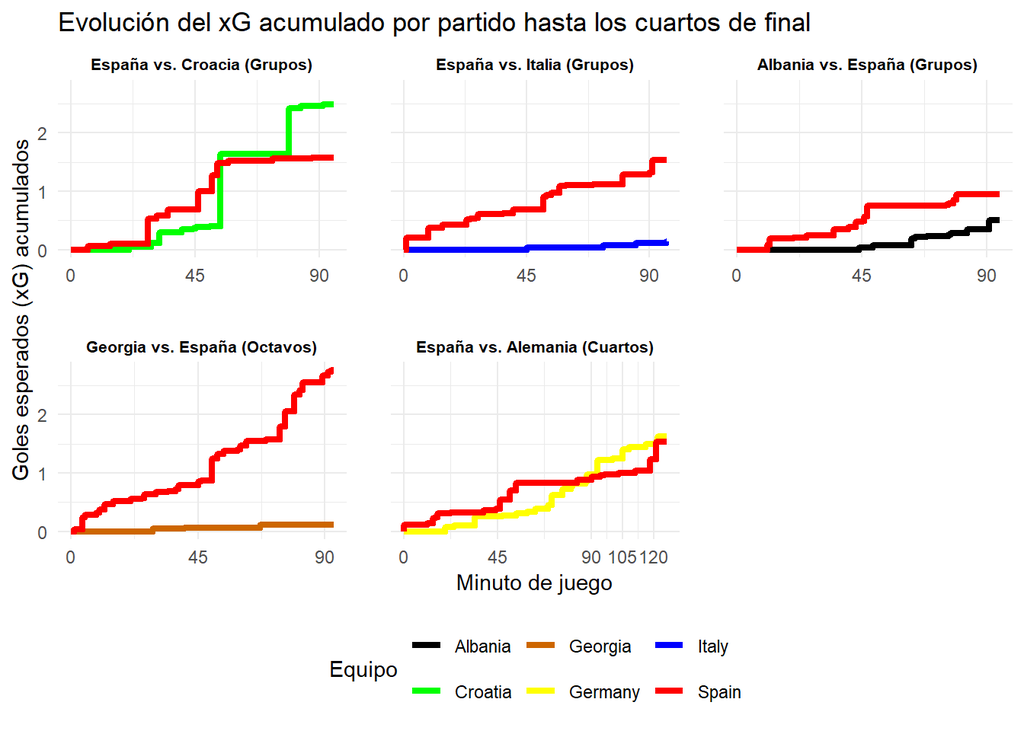

```r
# Leemos los datos que vamos a utilizar
datos <- read_csv("tiros_espana.csv")

# Generamos minuto_cero para que posteriormente nuestros gráficos empiecen en el minuto 0 con xG=0
minuto_cero <- datos %>%
  distinct(match_id, team.name) %>%
  mutate(minute = 0, second = 0, shot.statsbomb_xg = 0)
# Hacemos lo mismo para el minuto final para que aunque no haya tiros se siga mostrando la linea de los goles esperados hasta el final.
minuto_final <- datos %>%
  distinct(match_id, team.name) %>%
  mutate(
    # Seleccionamos la duración de cada partido para ampliar la gráfica hasta donde sea necesario
    minute = case_when(
      match_id == 3930160 ~ 95.15,  # España vs. Croacia
      match_id == 3930172 ~ 96.23,  # España vs. Italia
      match_id == 3930179 ~ 94.62,  # Albania vs. España
      match_id == 3941018 ~ 93.08,  # Georgia vs. España
      match_id == 3942226 ~ 126.10   # España vs. Alemania (con prórroga)
    ),
    second = 0,
    shot.statsbomb_xg = 0
  )

# Añadimos a la tabla de nuestros datos las filas de minuto_cero y minuto_final
xg_acumulado <- datos %>%
  bind_rows(minuto_cero,minuto_final) %>%
  # Filtramos por los partidos que nos interesan
  filter(match_id %in% c(3930160, 3930172, 3930179, 3941018, 3942226)) %>%

  # Añadimos otra variable para que al representar el gráfico se genere un nombre para cada partido
  mutate(
    Partido = case_when(
      match_id == 3930160 ~ "España vs. Croacia (Grupos)",
      match_id == 3930172 ~ "España vs. Italia (Grupos)",
      match_id == 3930179 ~ "Albania vs. España (Grupos)",
      match_id == 3941018 ~ "Georgia vs. España (Octavos)",
      match_id == 3942226 ~ "España vs. Alemania (Cuartos)"
    ),
    # Generamos un factor asociado a Partido para así ordenar los partidos en el orden del campeonato
    Partido = factor(Partido, levels = c(
      "España vs. Croacia (Grupos)", "España vs. Italia (Grupos)",
      "Albania vs. España (Grupos)", "Georgia vs. España (Octavos)",
      "España vs. Alemania (Cuartos)"
    ))
  ) %>%

  # Ordenamos los datos según el partido, el equipo y el minuto del partido para hacer la suma
  arrange(Partido, team.name, minute, second) %>%
  # Agrupamos por partido y equipo
  group_by(Partido, team.name) %>%
  # Calculamos el xG de cada equipo en cada partido
  mutate(xg_total_acumulado = cumsum(shot.statsbomb_xg)) %>%
  ungroup()

# Generamos el gráfico con geom_step() para una mejor visualización. Dibujamos el xG acumulado por minuto
ggplot(xg_acumulado, aes(x = minute, y = xg_total_acumulado, color = team.name)) +
  geom_step(size = 1.5) + #elegimos el grosor de la línea
  facet_wrap(~Partido, scales="free_x", ncol = 3) + # Dividimos el gráfico por partido y permitimos que cada panel tenga su propia escala en el eje x
  scale_color_manual(values = c( #elegimos los colores asociados a cada equipo
    "Spain" = "red", "Croatia" = "green", "Italy" = "blue",
    "Albania" = "black", "Georgia" = "darkorange3", "Germany" = "yellow"
  )) +
  scale_x_continuous(breaks = c(0, 45, 90, 105, 120)) + # Generamos marcas en el eje x para representar el inicio, final y descansos del partido
  theme_minimal() + # Lo usamos para limpiar el gráfico
  labs(# Generamos el título y las etiquetas del gráfico
    title = "Evolución del xG acumulado por partido hasta los cuartos de final",
    x = "Minuto de juego",
    y = "Goles esperados (xG) acumulados",
    color = "Equipo"
  ) +
  theme( # Mejoramos la estética final modificando la leyenda y añadiendo separación entre gráficos
    legend.position = "bottom",
    strip.text = element_text(face = "bold", size = 8, color = "black"),
    panel.spacing = unit(1.5, "lines"),
  )
```

Con esta visualización queda reflejado el dominio en ataque de España en los partidos de Italia, Albania y Georgia, destacando la superioridad aplastante ante la selección georgiana. Este hecho se verá reforzado por la posterior visualización que demostrará la hegemonía de España en todas las facetas del juego ante estos rivales.

En cuanto a los otros dos partidos no podemos apreciar este control. Frente a Alemania, se puede observar que hubo momentos de superioridad en este ámbito para ambos equipos, destacando una gran igualdad. De hecho, cabe señalar que este encuentro llegó a la prórroga, decidiéndose gracias a un fantástico cabezazo de Mikel Merino. En lo referente al partido ante la selección comandada por Luka Modric, el gráfico parece mostrar un predominio croata a lo largo de la segunda parte. Pese a esto, queda reflejado que este hecho se debe a dos eventos aislados, es decir, dos ocasiones claras que Croacia no materializó. A continuación, trataremos de comprobar con nuevas visualizaciones que esta situación no se generaliza a las demás facetas del juego.

### “La Roja” ante Italia, Albania y Georgia

Para demostrar la superioridad general de nuestra selección ante estos tres rivales vamos a realizar un gráfico de barras mediante geom_col(). En este podremos analizar múltiples aspectos del juego, como los pases o regates completados por cada equipo así como los despejes o los duelos ganados por cada combinado.

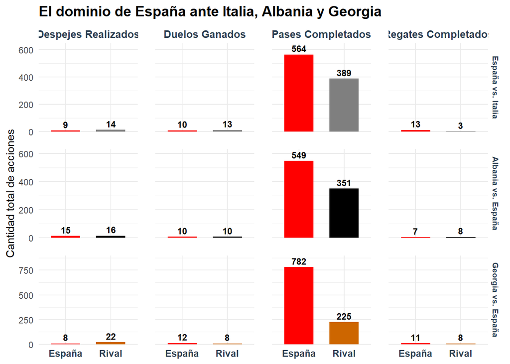

```r
# En primer lugar leemos los archivos
df_pases    <- read.csv("pases_espana.csv", stringsAsFactors = FALSE)
df_regates  <- read.csv("regates_espana.csv", stringsAsFactors = FALSE)
df_duelos   <- read.csv("duelos_espana.csv", stringsAsFactors = FALSE)
df_despejes <- read.csv("despejes_espana.csv", stringsAsFactors = FALSE)

# Seleccionamos los partidos que nos interesan
partidos_interes <- c(3930172, 3930179, 3941018)

# ANÁLISIS DE LOS DATOS

pases_resumen <- df_pases %>%
  # Seleccionamos los partidos de interés y filtramos los pases completados (si tiene un na significa que se completó)
  filter(match_id %in% partidos_interes, is.na(pass.outcome.name)) %>%
  # Los agrupamos concretamente por partido y equipo para así poder estudiar los pases individualmente
  group_by(match_id, team.name) %>%
  # n() cuenta cuantas filas hay en el conjunto de datos que hemos agrupado previamente
  summarise(Cantidad = n(), .groups = "drop") %>%
  mutate(Metrica = "Pases Completados")

# Repetimos el mismo proceso para los regates
regates_resumen <- df_regates %>%
  filter(match_id %in% partidos_interes, dribble.outcome.name == "Complete") %>%
  group_by(match_id, team.name) %>%
  summarise(Cantidad = n(), .groups = "drop") %>%
  mutate(Metrica = "Regates Completados")

# Repetimos el proceso para los duelos
duelos_resumen <- df_duelos %>%
  # En este caso solo seleccionamos los duelos ganados y que hacen que posteriormente el equipo mantenga la posesión
  filter(match_id %in% partidos_interes, duel.outcome.name %in% c("Won", "Success In Play")) %>%
  group_by(match_id, team.name) %>%
  summarise(Cantidad = n(), .groups = "drop") %>%
  mutate(Metrica = "Duelos Ganados")

# Repetimos para los despejes
despejes_resumen <- df_despejes %>%
  filter(match_id %in% partidos_interes) %>%
  group_by(match_id, team.name) %>%
  summarise(Cantidad = n(), .groups = "drop") %>%
  mutate(Metrica = "Despejes Realizados")

# Generamos una tabla que reuna los datos anteriores
datos_grafico <- bind_rows(pases_resumen, regates_resumen, duelos_resumen, despejes_resumen) %>%
  mutate(
    # Generamos una variable auxiliar para poder representar el partido jugado en las gráficas
    Partido = case_when(
      match_id == 3930172 ~ "España vs. Italia",
      match_id == 3930179 ~ "Albania vs. España",
      match_id == 3941018 ~ "Georgia vs. España"
    ),
    # Le asociamos un factor de forma que las gráficas salgan en el mismo orden del campeonato
    Partido = factor(Partido, levels = c("España vs. Italia", "Albania vs. España", "Georgia vs. España")),

    # En el eje X escribimos o bien España o bien Rival según de quien sean las estadísticas
    Equipo_Grupo = if_else(team.name == "Spain", "España", "Rival"),
    Equipo_Grupo = factor(Equipo_Grupo, levels = c("España", "Rival")),

    # Generamos esta variable para posteriormente cambiar el color de cada equipo
    Equipo_Nombre = if_else(team.name == "Spain", "España", team.name),
    Equipo_Nombre = factor(Equipo_Nombre, levels = c("España", "Italia", "Albania", "Georgia"))
  )

# Generamos el gráfico

# En x usamos 'Equipo_Grupo' para que solo salga Rival (en caso contrario se solaparían los nombres) y fill usa 'Equipo_Nombre' para diferenciar el color según el rival
ggplot(datos_grafico, aes(x = Equipo_Grupo, y = Cantidad, fill = Equipo_Nombre)) +

  # Generamos las barras del gráfico
  geom_col(width = 0.65, show.legend = FALSE) +

  # En cada estadística añadimos el número
  geom_text(aes(label = Cantidad), vjust = -0.4, fontface = "bold", size = 3.2) +

  # Usamos facet para dividir el gráfico en los 3 partidos
  facet_grid(Partido ~ Metrica, scales = "free_y") +

  # Usamos un color para cada selección
  scale_fill_manual(
    values = c(
      "España"  = "red",
      "Italy"   = "blue",
      "Albania" = "black",
      "Georgia" = "darkorange3"
    )
  ) +

  # Añadimos título y etiquetas
  labs(
    title = "El dominio de España ante Italia, Albania y Georgia",
    x = NULL,
    y = "Cantidad total de acciones"
  ) +

  # Ajustamos los límites para que el número de los pases se vea correctamente, en caso de omitir esto no habría espacio suficiente
  expand_limits(y = 0) +
  scale_y_continuous(expand = expansion(mult = c(0, 0.15))) +

  theme_minimal() +
  theme(
    # Adaptamos el tamaño de las etiquetas y del título, dejamos espacio entre los gráficos
    strip.text.x = element_text(face = "bold", size = 10, color = "#2c3e50"),
    strip.text.y = element_text(face = "bold", size = 8, color = "#2c3e50"),
    plot.title = element_text(face = "bold", size = 14),
    panel.spacing = unit(1.2, "lines"),

    # Adaptamos el tamaño del texto del eje X
    axis.text.x = element_text(face = "bold", size = 9.5, color = "#2c3e50")
  )
```

Mediante este gráfico podemos concluir claramente lo mencionado previamente, el dominio de España frente a Italia, Albania y Georgia fue incontestable. Analizando los datos observamos que España supera aplastantemente a las tres selecciones en cuanto al volumen de pases completados. Asimismo en los partidos contra Italia y Georgia apreciamos que necesita realizar menos despejes que sus rivales. Esto demuestra que el conjunto español siempre busca el juego en corto, logrando evitar en la mayoría de ocasiones la presión rival.

En lo referente a estos dos partidos, también podemos observar la superioridad de España en los regates, gracias principalmente a la calidad de nuestros extremos, Lamine Yamal y Nico Williams. Sin embargo, en los duelos ganados observamos matices distintos. España fue superior a Georgia en este aspecto, observando así en definitiva el sometimiento sufrido por los georgianos que se vio superado en todos los aspectos del juego. Mientras tanto, en el duelo con el conjunto azzurro España fue inferior en las disputas, mostrando que este fue un choque de gran exigencia física para el conjunto comandado por Luis de la Fuente.

Por otro lado, en el partido contra Albania el análisis nos muestra una mayor igualdad en regates, despejes y duelos ganados. Esta pérdida de volumen ofensivo de “La Roja” se entiende con el contexto del partido, España llegaba habiendo asegurado la primera plaza afrontando el choque con bastantes suplentes. Pese a esto, el juego asociativo español siguió predominando, demostrando que el estilo es innegociable sin importar el once.

A continuación, para apoyar de forma más visual el estilo de juego español y el sometimiento al que lleva a sus rivales vamos a generar un gráfico mediante geom_points() en el que podremos visualizar la ubicación en la que realizan los pases cada selección en cada uno de los encuentros:

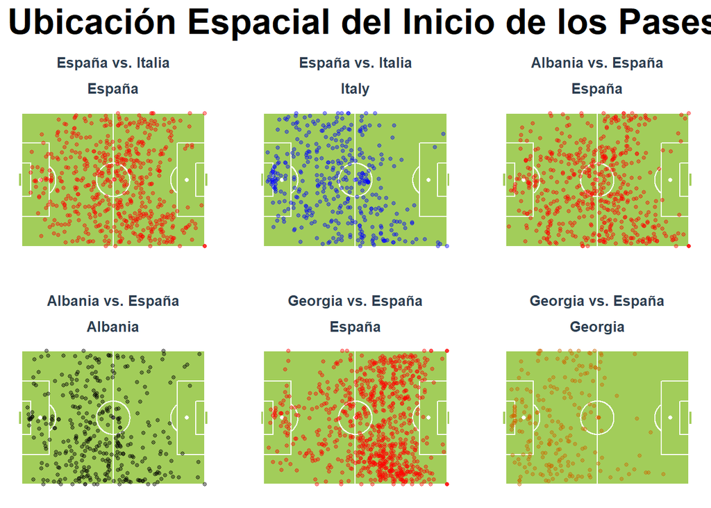

```r
# Tomamos los datos que vamos a usar
df_pases <- read.csv("pases_espana.csv", stringsAsFactors = FALSE)

# Utilizamos el id correspondiente a los 3 partidos a analizar
partidos_interes <- c(3930172, 3930179, 3941018)

# Tomamos solo los datos de los partidos que nos interesan
pases_mapa <- df_pases %>%
  filter(match_id %in% partidos_interes, is.na(pass.outcome.name)) %>%
  mutate(
    # Creamos los nombres de los partidos
    Partido = case_when(
      match_id == 3930172 ~ "España vs. Italia",
      match_id == 3930179 ~ "Albania vs. España",
      match_id == 3941018 ~ "Georgia vs. España"
    ),
    # Pasamos partido a factor para que salgan en el mismo orden que en el campeonato
    Partido = factor(Partido, levels = c("España vs. Italia", "Albania vs. España", "Georgia vs. España")),

    # Asociamos los nombres en español a cada equipo para la hora de graficar
    Equipo = if_else(team.name == "Spain", "España", team.name),
    Equipo = factor(Equipo, levels = c("España", "Italy", "Albania", "Georgia"))
  )


# Generamos el gráfico

ggplot(data = pases_mapa, aes(x = location_x, y = location_y, col = Equipo)) +

  # Gracias a ggsoccer generamos el campo de fútbol para que quede más visual
  annotate_pitch(dimensions = pitch_statsbomb, fill = "darkolivegreen3", colour = "white") +

  # Generamos puntos para los datos de pases
  geom_point(alpha = 0.4, size = 1.0) +

  # Usamos facet para poder observar todos los datos en un gráfico
  facet_wrap(~ Partido + Equipo, ncol = 3) +

  # Asignamos un color a cada selección
  scale_color_manual(
    values = c(
      "España"  = "red",
      "Italy"   = "blue",
      "Albania" = "black",
      "Georgia" = "darkorange3"
    )
  ) +

  # Generamos el título y etiquetas
  labs(
    title = "Ubicación Espacial del Inicio de los Pases",
    x = NULL, y = NULL
  ) +

  theme_minimal() +
  theme(
    # Modificamos el estílo del título
    plot.title = element_text(face = "bold", size = 25),

    # Modificamos el estilo de los títulos para cada campo
    strip.text = element_text(face = "bold", size = 10, color = "#2c3e50"),

    # Limpiamos el gráfico para que solo se vea el campo
    panel.grid.major = element_blank(),
    panel.grid.minor = element_blank(),
    axis.text.x = element_blank(),
    axis.text.y = element_blank(),

    # Generamos un espaciado entre los campos
    panel.spacing.x = unit(1.5, "lines"),
    panel.spacing.y = unit(1.2, "lines"),

    # Quitamos la leyenda al no ser necesaria
    legend.position = "none"
  )
```

Gracias a esta visualización queda claro que podemos afirmar claramente la clara hegemonía en el juego asociativo de “La Roja”. En estos gráficos no solo observamos un volumen de pases muy superior a las demás selecciones sino que también apreciamos un mayor juego ofensivo y una presión muy efectiva.

Al analizar los mapas de puntos podemos apreciar claramente como los rivales realizan la mayor parte de los pases en campo propio. Esto nos permite observar el acoso asfixiante al que España somete al resto de selecciones. El caso más extremo queda registrado en el caso de Georgia, llegando incluso a impedir que pasen prácticamente del centro del campo.

Asimismo, podemos evidenciar el predominio español en el campo contrario, intentando encerrar al rival constantemente. De igual forma, podemos advertir el mayor volumen ofensivo de la selección por las bandas, apoyándose en sus dos jugadores de mayor calidad buscando generar situaciones de uno contra uno constantemente para desbordar.